# R Notebook

# Procesamiento Preliminar

Cargar las librerías que se van a utilizar.

```r
library(tidyverse)
library(magrittr)
library(sf)
library(tmap)
```

## Datos Iniciales Matriz OD

En este análisis se van usar datos únicamente de la Matriz Origen Destino 2017 de Pereira y Dosquebradas. Una copia de los datos se encuentran en mi [Repositorio](https://github.com/orlando-sabogal/Encuesta-Matriz-OD-Pereira-2017). A continuación se cargan algunos archivos directamente desde github.

```r
# Viajes <- read_delim("https://raw.githubusercontent.com/orlando-sabogal/Encuesta-Matriz-OD-Pereira-2017/master/BasesDeDatos/06_Viajes.txt", delim = ";")
#
# Hogares <- read_delim("https://raw.githubusercontent.com/orlando-sabogal/Encuesta-Matriz-OD-Pereira-2017/master/BasesDeDatos/01_Hogares.txt", delim = ";")
#
# ModuloD <- read_delim("https://raw.githubusercontent.com/orlando-sabogal/Encuesta-Matriz-OD-Pereira-2017/master/BasesDeDatos/02_Modulo_C.txt", delim = ";")
#
# Personas <- read_delim("https://raw.githubusercontent.com/orlando-sabogal/Encuesta-Matriz-OD-Pereira-2017/master/BasesDeDatos/03_Personas.txt", delim = ";")
Viajes <- read.table("https://raw.githubusercontent.com/orlando-sabogal/Encuesta-Matriz-OD-Pereira-2017/master/BasesDeDatos/06_Viajes.txt", sep = ";", header = TRUE)
Hogares <- read.table("https://raw.githubusercontent.com/orlando-sabogal/Encuesta-Matriz-OD-Pereira-2017/master/BasesDeDatos/01_Hogares.txt", sep = ";", header = TRUE)
ModuloD <- read.table("https://raw.githubusercontent.com/orlando-sabogal/Encuesta-Matriz-OD-Pereira-2017/master/BasesDeDatos/02_Modulo_C.txt", sep = ";", header = TRUE)
Personas <- read.table("https://raw.githubusercontent.com/orlando-sabogal/Encuesta-Matriz-OD-Pereira-2017/master/BasesDeDatos/03_Personas.txt", sep = ";", header = TRUE)
```

La matriz origen destino es una encuesta realizada usando conceptos estadísticos y de muestreo de tal manera que sus resultados se puedan generalizar. Para el archivo de *Viajes* esto se ve reflejado en la variable *Factor de Expansión (F_EXP)* que indica la cantidad de viajes **reales** que se estima con cada viaje. Hay que hacer una transformación inicial de la variable *F_EXP.*

```r
Viajes %<>% mutate(FactorExpansion = str_replace_all( F_EXP, ",", ".")) %>%
  mutate(FactorExpansion = as.numeric(FactorExpansion))
```

Con los datos de *Hogares* y de *Personas* sucede lo mismo.

```r
Hogares %<>% mutate(FactorExpansion = str_replace_all( F_EXP, ",", ".")) %>%
  mutate(FactorExpansion = as.numeric(FactorExpansion))
Personas %<>% mutate(FactorExpansion = str_replace_all( F_EXP, ",", ".")) %>%
  mutate(FactorExpansion = as.numeric(FactorExpansion))
```

El objeto *Viajes* incluye las variables **D_013** y **M_PRINCIPAL** que corresponden a la codificación para el propósito y modo princial del viaje. Del [formato de la encuesta](https://github.com/orlando-sabogal/Encuesta-Matriz-OD-Pereira-2017/blob/master/BasesDeDatos/FormatoEncuesta/EncuestaOD2017_Pereira.pdf) se identifica que significa cada código y se ingresan manualmente.

```r
Propositos <- tibble(
  D_013 = c(1, 2, 3, 4, 5, 6, 7, 8, 9, 10, 11, 12, 13, 14, 77),
  Proposito = c("Trabajar", "Asuntos de Trabajo", "Estudiar", "Recibir Antencion en Salud",
                "Ver a Alguien", "Volver a Casa", "BuscarDejar Alguien", "BuscarDejar Algo",
                "ComerTomar Algo", "Compras", "Tramites", "Recreacion",
                "Buscar Trabajo", "Lugar de Culto", "Otra"))
Modo <- tibble(
  M_PRINCIPAL = c( seq(1,12), seq(20,25) ,30),
  Modo = c("Megabus Troncal", "Megabus Alimentador",
           "Bus Urbano", "Bus Intermunicipal", "Bus EscaleraChiva", "CamperoJeep",
           "Taxi", "Transporte Escolar", "Bus PrivadodeEmpresa",
           "Transporte Individual por APP", "Mototaxi", "Motocarro de PasajeroCarga",
           "Bicicleta", "Bicicleta con Motor",
           "Moto Conductor", "Moto Pasajero",
           "Vehiculo Privado Conductor", "Vehiculo Privado Pasajero",
           "A pie"))
```

Los datos ingresados manualmente se unen al archivo de *Viajes*

```r
Viajes %<>% left_join(Propositos)
Viajes %<>% left_join(Modo)
```

## Archivos Geográficos

en la carpeta */ZatsPereiraDosquebradas/* está el archivo gegráfico (formato ESRI shape) de las zonas de análisis de transporte (ZAT) y la zona Urbana de Pereira y Dosquebradas que es donde los análisis de van a enfocar más adelante. Este segundo arhivo fue construído a partir del archivo de [ZATs](https://github.com/orlando-sabogal/Encuesta-Matriz-OD-Pereira-2017/tree/master/BasesDeDatos/ZAT%20Shapefiles)

```r
Zonas <- st_read("ZatsPereiraDosquebradas/ZAT_rev.shp")
Zonas <- st_transform(Zonas, 4326)

ZonasUrbanas <- st_read("ZatsPereiraDosquebradas/ZatsPereiraDosquebradas.shp")
ZonasUrbanas <- st_transform(ZonasUrbanas, 4326)
```

### Calcular Estratos ZATs

Los estratos dentro de los ZATs no son homogéneos. El estrato es asignado a cada ZAT como el dato más frecuente (moda).

```r
Mode <- function(x) {
ux <- unique(x)
ux[which.max(tabulate(match(x, ux)))]
}

ZonesEstrato <- Viajes %>% select(ZAT_INI,FORMULARIO) %>%
  #mutate(FORMULARIO = as.numeric(FORMULARIO)) %>%
  left_join(Hogares %>% select(FORMULARIO, Municipio, Estrato)) %>%
  drop_na(ZAT_INI) %>%
  group_by(ZAT_INI) %>%
  summarise(Estrato = Mode(Estrato))
```

# Análisis Iniciales

```r
Hogares %>%
  group_by(Municipio) %>%
  summarise(TotalEncuestas = n(), TotalHogares = sum(FactorExpansion))
```

| Municipio | TotalEncuestas | TotalHogares |
| --- | --- | --- |
| Dosquebradas | 444 | 61693.23 |
| La Virginia | 121 | 10049.80 |
| Pereira | 2758 | 161296.71 |

La tabla anterior muestra el total de hogares encuestados en cada municipio y la respectiva estimación.

See the [Color Configuration](https://color.adobe.com/search?q=white)

## Viajes por modo

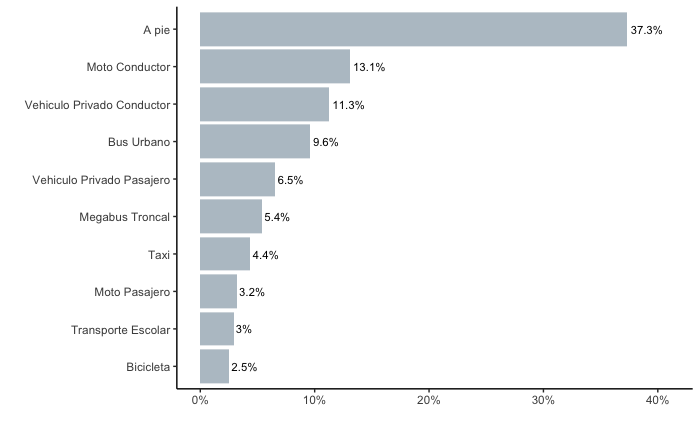

```r
ModosResumen <- Viajes %>% group_by(Modo) %>%
  summarise(TotalViajes = sum(FactorExpansion)) %>%
  drop_na(Modo) %>%
  arrange(TotalViajes) %>%
  mutate(Modo = factor(Modo, levels = Modo),
         Porcentaje = TotalViajes/sum(TotalViajes),
         Etiqueta = paste( round(Porcentaje*100,1), "%", sep = "" ))
ModosResumen %>% filter(Porcentaje >0.02) %>%
  ggplot(aes(x = Modo, y = Porcentaje)) +
    geom_bar(stat = "identity", fill = "#B8C4CC") +
    geom_text( aes(label = Etiqueta), hjust = -0.1, size = 3) +
    coord_flip() +
    scale_y_continuous(breaks = c(0,0.1,0.2,0.3,0.4),
                       labels = c("0%", "10%", "20%", "30%", "40%"),
                       limits = c(0,0.41)) +
    xlab("") + ylab("") +
    theme_classic()
```

### Viajes por modo por ciudad

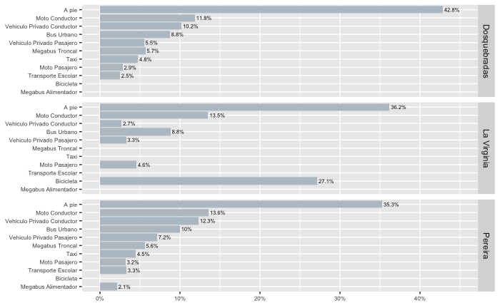

```r
ModosFactor <- as.character(ModosResumen$Modo)
Viajes %>%
  left_join(Hogares %>% select(FORMULARIO, Municipio, Estrato)) %>% # Si no selecciono las variables es posible que me haga el JOIN usando otras variables en común que tengan como F_EXP
  group_by(Municipio, Modo) %>%
  summarise(TotalViajes = sum(FactorExpansion)) %>%
  drop_na(Modo) %>%
  mutate(Modo = factor(Modo, levels = ModosFactor, label = ModosFactor),
         Porcentaje = TotalViajes/sum(TotalViajes),
         Etiqueta = paste( round(Porcentaje*100,1), "%", sep = "" )) %>%
  filter(Porcentaje > 0.02) %>%
  ggplot(aes(x = Modo, y= Porcentaje) ) +
    geom_bar(stat = "identity", fill = "#B8C4CC") +
    geom_text( aes(label = Etiqueta), hjust = -0.1, size = 2) +
    facet_grid(Municipio ~ .) +
    coord_flip() +
   scale_y_continuous(breaks = c(0,0.1,0.2,0.3,0.4),
                       labels = c("0%", "10%", "20%", "30%", "40%"),
                       limits = c(0,0.45)) +
    theme(axis.text = element_text(size = 6.1),
          axis.title.x = element_blank(),
          axis.title.y = element_blank())
```

## Perfil Horario

```r
Viajes %<>% mutate(Hour = MIN_INICIO/60) %>%
  mutate(HourRound = floor(Hour)) %>%
  mutate(HourFraction = Hour - HourRound)
Viajes %<>% mutate(HourMedia = if_else(HourFraction<0.5,0,0.5)) %>%
  mutate(Hour = HourRound + HourMedia) %>%
  select(-HourRound, -HourFraction, -HourMedia)
```

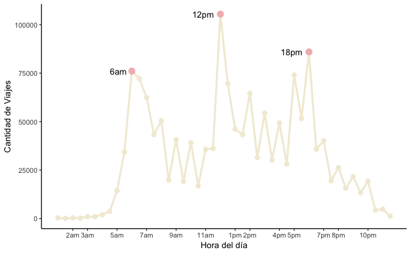

```r
PerfilHorario <- Viajes %>% group_by(Hour) %>%
  summarise(TotalViajes = sum(FactorExpansion)) %>%
  arrange(Hour) %>%
  mutate(Grupo = 1)#%>%
  #mutate(Hour = factor(Hour, Hour, Hour))
PerfilPicos <- PerfilHorario %>%
  arrange(desc(TotalViajes)) %>%
  slice(1:3) %>%
  mutate(Etiqueta = if_else(Hour < 12,
                            paste(Hour,"am", sep = ""),
                            paste(Hour,"pm", sep = "")))
ggplot(PerfilHorario) +
  geom_point(aes(x = Hour, y = TotalViajes), color = "#F2ECD8", size = 2.5) +
  geom_line(aes(x = Hour, y = TotalViajes, group = Grupo), color = "#F2ECD8", size = 1.2) +
  geom_point(data = PerfilPicos,
            aes(x = Hour, y = TotalViajes), colour = "#F2BBBB", size = 3.5) +
  geom_text(data = PerfilPicos,
            aes(x = Hour, y = TotalViajes, label = Etiqueta),
            hjust = 1.3) +
  scale_x_continuous(breaks = c(2,3,5,7,9,11,13,14,16,17,19,20,22),
                     labels = c("2am", "3am","5am","7am","9am","11am",
                                "1pm","2pm","4pm","5pm","7pm","8pm","10pm")) +
  xlab("Hora del día") + ylab("Cantidad de Viajes") + theme_classic()
```

### Perfil Horario Viajes Motorizados

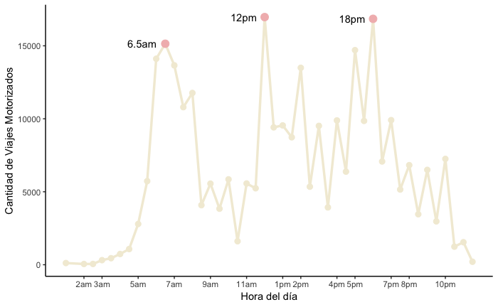

```r
PerfilHorario <- Viajes %>%
  filter(M_PRINCIPAL %in% c(22,23.24,25)) %>% #Moto y carro, conductor y pasajero
  group_by(Hour) %>%
  summarise(TotalViajes = sum(FactorExpansion)) %>%
  arrange(Hour) %>%
  mutate(Grupo = 1)#%>%
  #mutate(Hour = factor(Hour, Hour, Hour))
PerfilPicos <- PerfilHorario %>%
  arrange(desc(TotalViajes)) %>%
  slice(1:3) %>%
  mutate(Etiqueta = if_else(Hour < 12,
                            paste(Hour,"am", sep = ""),
                            paste(Hour,"pm", sep = "")))
ggplot(PerfilHorario) +
  geom_point(aes(x = Hour, y = TotalViajes), color = "#F2ECD8", size = 2.5) +
  geom_line(aes(x = Hour, y = TotalViajes, group = Grupo), color = "#F2ECD8", size = 1.2) +
  geom_point(data = PerfilPicos,
            aes(x = Hour, y = TotalViajes), colour = "#F2BBBB", size = 3.5) +
  geom_text(data = PerfilPicos,
            aes(x = Hour, y = TotalViajes, label = Etiqueta),
            hjust = 1.3) +
  scale_x_continuous(breaks = c(2,3,5,7,9,11,13,14,16,17,19,20,22),
                     labels = c("2am", "3am","5am","7am","9am","11am",
                                "1pm","2pm","4pm","5pm","7pm","8pm","10pm")) +
  xlab("Hora del día") + ylab("Cantidad de Viajes Motorizados") + theme_classic()
```

Hay tres picos y para la información que se va a tomar en la API de google se va a tomar como pico los siguientes 4 periodos de tiempo:

- 6:00 am a 8:00 am,
- 11:30 am a 12:30 am
- 1:30 pm a 2:00 pm
- 5:30 pm a 18:30 pm

## Tiempo de Viaje

```r
Viajes %<>% mutate(TravelTime = MIN_FIN - MIN_INICIO) %>%
  filter(TravelTime>0) %>%
  filter(TravelTime<180)
```

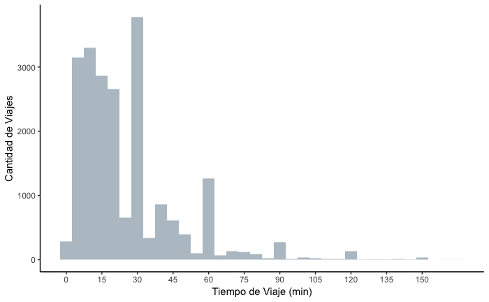

```r
ggplot(data = Viajes) +
  geom_histogram(aes(x = TravelTime), binwidth = 5, fill = "#B8C4CC") +
  scale_x_continuous(breaks = seq(0,150,15)) +
  xlab("Tiempo de Viaje (min)") + ylab("Cantidad de Viajes") + theme_classic()
```

### Tiempos de Viaje por modo

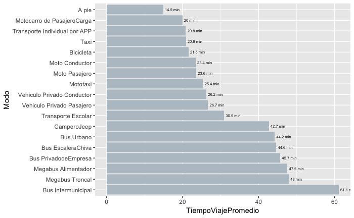

```r
#ModosFactor <- as.character(ModosResumen$Modo)
ViajesReducido <- Viajes %>%
  left_join(Hogares %>% select(FORMULARIO, Municipio, Estrato)) %>%
  select(FORMULARIO, Municipio, Estrato, Modo, M_PRINCIPAL, Proposito, ZAT_INI, ZAT_FIN, TravelTime, Hour)
ViajesReducido <- ViajesReducido %>% group_by(Modo) %>%
  summarise(TiempoViajePromedio = mean(TravelTime, na.rm = TRUE)) %>%
  drop_na(Modo) %>% arrange(desc(TiempoViajePromedio))
ModosFactorHERE <- as.character(ViajesReducido$Modo)
  ViajesReducido %>% mutate(Modo = factor(Modo, levels = ModosFactorHERE, label = ModosFactorHERE),
         Etiqueta = paste(round(TiempoViajePromedio,1),"min"," ")) %>%
  ggplot(aes(x = Modo, y= TiempoViajePromedio) ) +
    geom_bar(stat = "identity", fill = "#B8C4CC") +
    geom_text( aes(label = Etiqueta), hjust = -0.1, size = 2) +
    coord_flip()
```

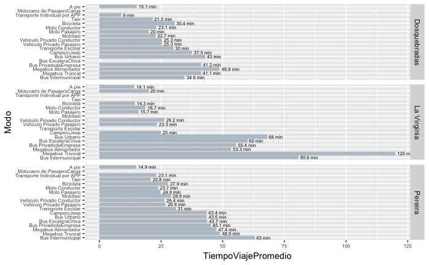

```r
ViajesReducido <- Viajes %>%
  left_join(Hogares %>% select(FORMULARIO, Municipio, Estrato)) %>%
  select(FORMULARIO, Municipio, Estrato, Modo, M_PRINCIPAL, Proposito, ZAT_INI, ZAT_FIN, TravelTime, Hour)
ViajesReducido <- ViajesReducido %>% group_by(Modo,Municipio) %>%
  summarise(TiempoViajePromedio = mean(TravelTime, na.rm = TRUE)) %>%
  drop_na(Modo) %>% arrange(desc(TiempoViajePromedio))
#ModosFactorHERE <- as.character(ViajesReducido$Modo)
ViajesReducido %>%  as_tibble() %>%
  mutate(Modo = factor(Modo, levels = ModosFactorHERE, label = ModosFactorHERE), Etiqueta = paste(round(TiempoViajePromedio,1),"min"," ")) %>%
  ggplot(aes(x = Modo, y= TiempoViajePromedio) ) +
    geom_bar(stat = "identity", fill = "#B8C4CC") +
    geom_text( aes(label = Etiqueta), hjust = -0.1, size = 2) +
    facet_grid(Municipio ~ .) +
    coord_flip() +
  theme(axis.text=element_text(size=6))
```

# Análisis Trabajo - Motorizado

```r
ViajesMotorizados <-  Viajes %>%
  filter(D_013 %in% c(1,2)) %>%
  filter(M_PRINCIPAL %in% c(22,23,24,25))
ViajesMotorizados_Pico <- ViajesMotorizados %>%
  filter(Hour %in% c(seq(6,8,0.5), 11.5, 12, 12.5, 13.5, 14, 17.5, 18, 18.30))
ViajesMotorizados_Valle <- ViajesMotorizados %>%
  filter(!Hour %in% c(seq(6,8,0.5), 11.5, 12, 12.5, 13.5, 14, 17.5, 18, 18.30))
OD_Pico <- ViajesMotorizados_Pico %>%
  group_by(ZAT_INI, ZAT_FIN) %>%
  summarise(TotalViajes = sum(FactorExpansion), TravelTimeMean = mean(TravelTime, na.rm = T))
OD_Pico <- OD_Pico[complete.cases(OD_Pico),]
TotalPico <- sum(OD_Pico$TotalViajes)
OD_Pico %<>% mutate(Porcentaje = TotalViajes/TotalPico)
OD_Valle <- ViajesMotorizados_Valle %>%
  group_by(ZAT_INI, ZAT_FIN) %>%
  summarise(TotalViajes = sum(FactorExpansion), TravelTimeMean = mean(TravelTime, na.rm = T))
OD_Valle <- OD_Valle[complete.cases(OD_Valle),]
TotalValle <- sum(OD_Valle$TotalViajes)
OD_Valle %<>% mutate(Porcentaje = TotalViajes/TotalValle)
```

```r
OD_Pico %<>% filter(ZAT_INI %in% Zonas$ZONA) %>% filter(ZAT_FIN %in% Zonas$ZONA)
OD_Valle %<>% filter(ZAT_INI %in% Zonas$ZONA) %>% filter(ZAT_FIN %in% Zonas$ZONA)
```

## Distancias entre esas zonas

```r
ZonasCentroids <- st_centroid(Zonas)
```

```r
OD_Pico %<>% mutate(Distancia = c(0))
for (i in 1:dim(OD_Pico)[1]){ #Mirar cómo implementar esto con map(), pero por ahora funciona
  Inicio <- ZonasCentroids %>% filter(ZONA==OD_Pico$ZAT_INI[i])
  Fin <- ZonasCentroids %>% filter(ZONA==OD_Pico$ZAT_FIN[i])
  Distance <- st_distance(Inicio, Fin) #meters
  OD_Pico$Distancia[i] <- as.numeric(Distance)
}
OD_Valle %<>% mutate(Distancia = c(0))
for (i in 1:dim(OD_Valle)[1]){ #Mirar cómo implementar esto con map(), pero por ahora funciona
  Inicio <- ZonasCentroids %>% filter(ZONA==OD_Valle$ZAT_INI[i])
  Fin <- ZonasCentroids %>% filter(ZONA==OD_Valle$ZAT_FIN[i])
  Distance <- st_distance(Inicio, Fin) #meters
  OD_Valle$Distancia[i] <- as.numeric(Distance)
}
```

```r
WalkingSpeed <- 1.4 #(m/s)
CyclingSpeed <- 4.15 #(m/s)
OD_Pico %<>% mutate(TravelTimeWalk = (Distancia/WalkingSpeed)/60,
                    TaverlTimeBici = (Distancia/CyclingSpeed)/60)
OD_Valle %<>% mutate(TravelTimeWalk = (Distancia/WalkingSpeed)/60,
                    TaverlTimeBici = (Distancia/CyclingSpeed)/60)
OD_Pico %<>% select(ZAT_INI, ZAT_FIN, Distancia, TravelTimeWalk, TaverlTimeBici)
OD_Valle %<>% select(ZAT_INI, ZAT_FIN, Distancia, TravelTimeWalk, TaverlTimeBici)
```

# Comparaciones

```r
CarroPico <- Viajes %>%
  filter(D_013 %in% c(1,2)) %>%
  filter(M_PRINCIPAL %in% c(24,25)) %>%
  filter(Hour %in% c(seq(6,8,0.5), 11.5, 12, 12.5, 13.5, 14, 17.5, 18, 18.30)) %>%
  group_by(ZAT_INI, ZAT_FIN) %>%
  summarise(TotalViajes = sum(FactorExpansion), TravelTimePrivate = mean(TravelTime, na.rm = T)) %>%
  left_join(OD_Pico)
#OD_Pico <- OD_Pico[complete.cases(OD_Pico),]
MotoPico <- Viajes %>%
  filter(D_013 %in% c(1,2)) %>%
  filter(M_PRINCIPAL %in% c(22,23)) %>%
  filter(Hour %in% c(seq(6,8,0.5), 11.5, 12, 12.5, 13.5, 14, 17.5, 18, 18.30))%>%
  group_by(ZAT_INI, ZAT_FIN) %>%
  summarise(TotalViajes = sum(FactorExpansion), TravelTimePrivate = mean(TravelTime, na.rm = T)) %>%
  left_join(OD_Pico)
CarroValle <- Viajes %>%
  filter(D_013 %in% c(1,2)) %>%
  filter(M_PRINCIPAL %in% c(24,25)) %>%
  filter(!Hour %in% c(seq(6,8,0.5), 11.5, 12, 12.5, 13.5, 14, 17.5, 18, 18.30))%>%
  group_by(ZAT_INI, ZAT_FIN) %>%
  summarise(TotalViajes = sum(FactorExpansion), TravelTimePrivate = mean(TravelTime, na.rm = T)) %>%
  left_join(OD_Valle)
MotoValle <- Viajes %>%
  filter(D_013 %in% c(1,2)) %>%
  filter(M_PRINCIPAL %in% c(22,23)) %>%
  filter(!Hour %in% c(seq(6,8,0.5), 11.5, 12, 12.5, 13.5, 14, 17.5, 18, 18.30))%>%
  group_by(ZAT_INI, ZAT_FIN) %>%
  summarise(TotalViajes = sum(FactorExpansion), TravelTimePrivate = mean(TravelTime, na.rm = T))  %>%
  left_join(OD_Valle)
```

```r
CarroPico %<>% filter(ZAT_INI %in% ZonasUrbanas$ZONA) %>% filter(ZAT_FIN %in% ZonasUrbanas$ZONA)
MotoPico %<>% filter(ZAT_INI %in% ZonasUrbanas$ZONA) %>% filter(ZAT_FIN %in% Zonas$ZONA)
CarroValle %<>% filter(ZAT_INI %in% ZonasUrbanas$ZONA) %>% filter(ZAT_FIN %in% ZonasUrbanas$ZONA)
MotoValle %<>% filter(ZAT_INI %in% ZonasUrbanas$ZONA) %>% filter(ZAT_FIN %in% ZonasUrbanas$ZONA)
```

# Cambio Modal

```r
ViajesMotorizados <-  Viajes %>%
  filter(D_013 %in% c(1,2)) %>%
  filter(M_PRINCIPAL %in% c(22,23,24,25))
ViajesMotorizadosOD <- ViajesMotorizados %>%
  group_by(ZAT_INI, ZAT_FIN) %>%
  summarise(TotalViajes = sum(FactorExpansion), TravelTimePrivate = mean(TravelTime, na.rm = T)) %>%
  as_tibble()
ViajesMotorizadosOD$Distancia <- c(0)
ViajesMotorizadosOD %<>% filter(ZAT_INI %in% ZonasUrbanas$ZONA) %>% filter(ZAT_FIN %in% ZonasUrbanas$ZONA)
ViajesMotorizadosOD %<>% filter(ZAT_INI %in% ZonasUrbanas$ZONA) %>% filter(ZAT_FIN %in% ZonasUrbanas$ZONA)
for (i in 1:dim(ViajesMotorizadosOD)[1]){
  Inicio <- ZonasCentroids %>% filter(ZONA==ViajesMotorizadosOD$ZAT_INI[i])
  Fin <- ZonasCentroids %>% filter(ZONA==ViajesMotorizadosOD$ZAT_FIN[i])
  Distance <- st_distance(Inicio, Fin) #meters
  ViajesMotorizadosOD$Distancia[i] <- as.numeric(Distance)
}
ViajesMotorizadosOD %<>% filter(Distancia>0)
```

```r
Trips <- sum(ViajesMotorizadosOD$TotalViajes)
ViajesMotorizadosOD %<>% arrange(Distancia) %>%
  mutate(ViajesAcum = cumsum(TotalViajes)) %>%
  mutate(PorAcumulado = ViajesAcum/Trips)
Referencia <- ViajesMotorizadosOD %>% slice(119,293,478,631) %>%
  mutate(EtViaje = paste(round(ViajesAcum,0), "Viajes"))
```

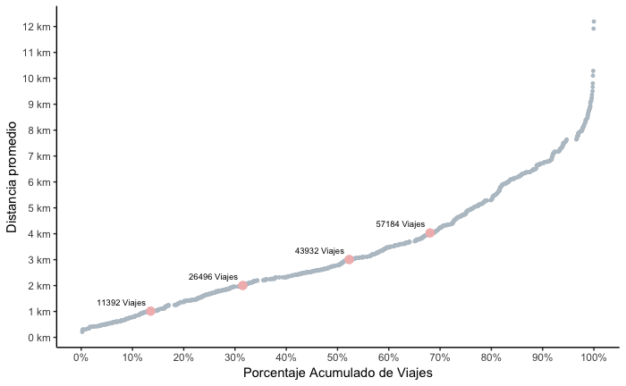

```r
ggplot() + geom_point(data = ViajesMotorizadosOD,
                      aes(x=PorAcumulado, y=Distancia), colour = "#B8C4CC", size = 1) +
  geom_point(data = Referencia, aes(x = PorAcumulado, y = Distancia),
             colour = "#F2BBBB", size = 3) +
  geom_text(data = Referencia, aes(x = PorAcumulado, y = Distancia, label = EtViaje),
            hjust = 1.1, vjust = -1, size = 2.5) +
xlab("Porcentaje Acumulado de Viajes") + ylab("Distancia promedio") +
  scale_x_continuous(breaks = seq(0,1,0.1),
                     labels = c("0%","10%","20%","30%","40%","50%","60%","70%","80%","90%","100%")) +
  scale_y_continuous(breaks = seq(0,12000,1000),
                     labels = paste(seq(0,12000,1000)/1000,"km")) +
  theme_classic()
```

# Modelo Potencial

## Carro

```r
TotalViajesCarroPico <- sum(CarroPico$TotalViajes)
#AtraccionCarroPico <- CarroPico %>% group_by(ZAT_FIN) %>% summarise(Atraccion = sum(TotalViajes))
AtraccionCarroPico <- Viajes %>% #Atracción de todos los viajes, de trabajo, no solamente carro pico
  filter(D_013 %in% c(1,2))  %>%
  group_by(ZAT_FIN) %>% summarise(Atraccion = sum(FactorExpansion))
CarroPico %<>% left_join(AtraccionCarroPico)
CarroPico %<>% mutate(Prop = TotalViajes/Atraccion)
CarroPico %<>% mutate(Acc = log(Prop))
CarroPico %<>% left_join(ZonesEstrato)
```

```r
Model1 <- lm(Acc ~ 0+TravelTimePrivate, data = CarroPico[CarroPico$Estrato == "1",])
Model2 <- lm(Acc ~ 0+TravelTimePrivate, data = CarroPico[CarroPico$Estrato == "2",])
Model3 <- lm(Acc ~ 0+TravelTimePrivate, data = CarroPico[CarroPico$Estrato == "3",])
Model4 <- lm(Acc ~ 0+TravelTimePrivate, data = CarroPico[CarroPico$Estrato == "4",])
Model5 <- lm(Acc ~ 0+TravelTimePrivate, data = CarroPico[CarroPico$Estrato == "5",])
Model6 <- lm(Acc ~ 0+TravelTimePrivate, data = CarroPico[CarroPico$Estrato == "6",])
#summary(lm(Acc ~ 0+TravelTimePrivate, data = CarroPico[CarroPico$Estrato %in% c(1,2), ]))
#summary(lm(Acc ~ 0+TravelTimePrivate, data = CarroPico[CarroPico$Estrato %in% c(3,4), ]))
#summary(lm(Acc ~ 0+TravelTimePrivate, data = CarroPico[CarroPico$Estrato %in% c(5,6), ]))
```

```r
ModelsResults <- tibble(Estrato = c(1,2,3,4,5,6),
                        Beta = c(summary(Model1)$coefficients[1],
                                 summary(Model2)$coefficients[1],
                                 summary(Model3)$coefficients[1],
                                 summary(Model4)$coefficients[1],
                                 summary(Model5)$coefficients[1],
                                 summary(Model6)$coefficients[1]),
                        R2 = c(summary(Model1)$r.squared[1],
                                 summary(Model2)$r.squared[1],
                                 summary(Model3)$r.squared[1],
                                 summary(Model4)$r.squared[1],
                                 summary(Model5)$r.squared[1],
                                 summary(Model6)$r.squared[1])
                        )
```

```r
ModelsResults
```

| Estrato | Beta | R2 |
| --- | --- | --- |
| 1 | -0.14353036 | 0.6292125 |
| 2 | -0.11010909 | 0.6283528 |
| 3 | -0.09229978 | 0.5708830 |
| 4 | -0.15031573 | 0.7486138 |
| 5 | -0.11206272 | 0.7047937 |
| 6 | -0.21396577 | 0.6958597 |

```r
AccesibilidadProyectada <- CarroPico %>% select(ZAT_INI, ZAT_FIN,
                                                TravelTimePrivate, TaverlTimeBici, Estrato, Atraccion)
AccesibilidadProyectada %<>% left_join(ModelsResults %>% select(-R2))
AccesibilidadProyectada %<>% mutate(AccPrivado = TravelTimePrivate*Beta,
                                    AccBici = TaverlTimeBici*Beta) %>%
  mutate(PropPrivado = exp(AccPrivado),
         PropBici = exp(AccBici)) %>%
  mutate(EmpleoPrivado = PropPrivado*Atraccion,
         EmpleoBici = PropBici*Atraccion) %>%
  mutate(DiffEmpleo = EmpleoBici - EmpleoPrivado)
```

```r
AccesibilidadDiffEmpleoZonas <- AccesibilidadProyectada %>% group_by(ZAT_INI) %>%
  summarise(Diferencia = sum(DiffEmpleo))
```

```r
AccesibilidadDiffEmpleoEstratos <- AccesibilidadProyectada %>% group_by(Estrato) %>%
  summarise(Diferencia = sum(DiffEmpleo))
```

```r
AccesibilidadDiffEmpleoEstratos
```

| Estrato | Diferencia |
| --- | --- |
| 1 | 3942.261 |
| 2 | 23852.945 |
| 3 | 88484.872 |
| 4 | 39043.903 |
| 5 | 22906.795 |
| 6 | 33534.143 |

# Mapas

## Concentración Viajes de Trabajo

```r
AtraccionCarroPico %<>% arrange(desc(Atraccion)) %>%
  drop_na(ZAT_FIN) %>%
  mutate(ViajesAcumulados = cumsum(Atraccion))
Total <- sum(AtraccionCarroPico$Atraccion)
AtraccionCarroPico %<>% mutate(PorcentajeAcumulado = ViajesAcumulados/Total)
```

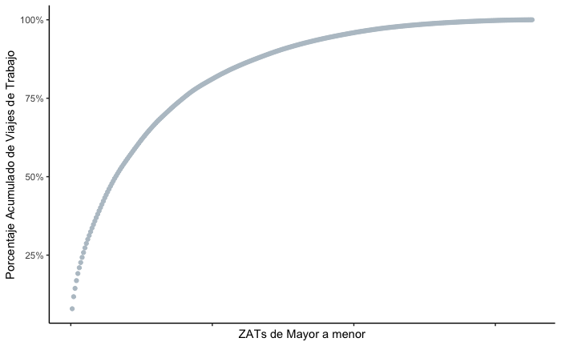

```r
ggplot(AtraccionCarroPico) + geom_point(aes(x = 1:dim(AtraccionCarroPico)[1],
                                            y = PorcentajeAcumulado),
                                        colour = "#B8C4CC") +
  xlab("ZATs de Mayor a menor") + ylab("Porcentaje Acumulado de Viajes de Trabajo") +
  scale_x_continuous(labels = NULL) +
  scale_y_continuous(breaks = c(0.25, 0.5, 0.75, 1), labels = c("25%","50%","75%","100%")) +
  theme_classic()
```

```r
AtraccionCarroPico %<>% mutate(Quartil = 1)

for ( i in 1:dim(AtraccionCarroPico)[1]){
  if(AtraccionCarroPico$PorcentajeAcumulado[i]>=0.25){AtraccionCarroPico$Quartil[i] = 2}
  if(AtraccionCarroPico$PorcentajeAcumulado[i]>=0.5){AtraccionCarroPico$Quartil[i] = 3}
  if(AtraccionCarroPico$PorcentajeAcumulado[i]>=0.75){AtraccionCarroPico$Quartil[i] = 4}
}
```

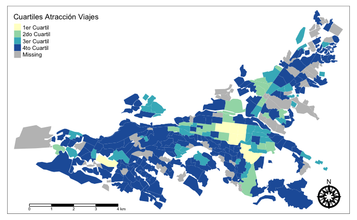

```r
ZonasQuartil <- ZonasUrbanas %>% left_join(AtraccionCarroPico, by = c("ZONA"="ZAT_FIN")) %>%
  mutate(Quartil = as.factor(Quartil))
Breaks <- c(1, 2, 3, 4)
Labels <- c("1er Cuartil", "2do Cuartil", "3er Cuartil", "4to Cuartil")
MyPalette <- c("#ffffcc", "#a1dab4", "#41b6c4", "#225ea8")
tm_shape(ZonasQuartil) + tm_polygons(col = "Quartil", title = "Cuartiles Atracción Viajes",
                                     palette = MyPalette, breaks = Breaks, labels = Labels,
                                     border.col = "black", lwd = 0) +
  tm_compass(size = 3, type = "rose", lwd = 3) +
    tm_scale_bar(position = c(0.06,0))
```

```r
tmap_mode("view")
```

```
tmap mode set to interactive viewing
```

```r
tm_shape(ZonasQuartil) + tm_polygons(alpha = 0.5)
```

[interactive chart not shown]

```r
tmap_mode("plot")
```

```
tmap mode set to plotting
```

```r
CuatroZats <- c(53,54,55,56)
ZonasPrinciaples <- ZonasQuartil %>% filter(ZONA %in% CuatroZats)
```

```r
ZonasPrinciaples <- ZonasQuartil %>% filter(ZONA %in% CuatroZats)
```

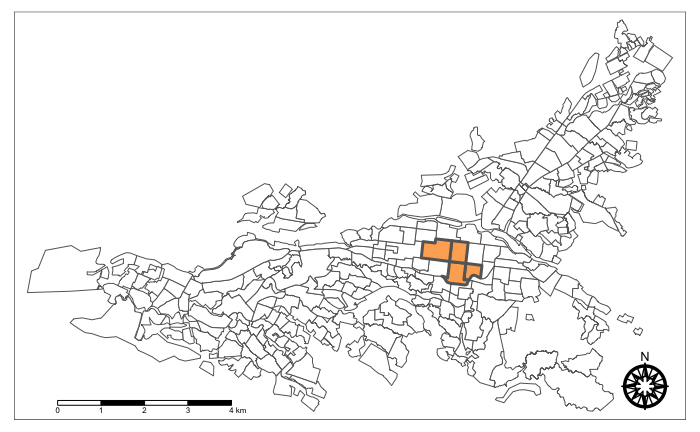

```r
tm_shape(ZonasQuartil) + tm_polygons(col = "white") +
  tm_shape(ZonasPrinciaples) + tm_polygons(col = "#fdae61", lwd = 3) +
  tm_compass(size = 3, type = "rose", lwd = 3) +
    tm_scale_bar(position = c(0.06,0))
```

¿Cuántos viajes de Dosquebradas van hacia esas zonas?

```r
PrincipalesCarroPico <- AccesibilidadProyectada %>% filter(ZAT_FIN %in% CuatroZats)
#sum(PrincipalesCarroPico$DiffEmpleo)
```

```r
mean(PrincipalesCarroPico$TravelTimePrivate)
```

```
[1] 23.60377
```

```r
mean(PrincipalesCarroPico$TaverlTimeBici)
```

```
[1] 12.08647
```

```r
sd(PrincipalesCarroPico$TravelTimePrivate)
```

```
[1] 10.47403
```

```r
sd(PrincipalesCarroPico$TaverlTimeBici)
```

```
[1] 7.486237
```

```r
PrincipalesCarroPico %>% group_by(Estrato) %>%
  summarise(TiempoViajeCarro = mean(TravelTimePrivate),
            TiempoViajeBici = mean(TaverlTimeBici))
```

| Estrato | TiempoViajeCarro | TiempoViajeBici |
| --- | --- | --- |
| 1 | 20.00000 | 17.449661 |
| 2 | 19.80000 | 15.011644 |
| 3 | 22.37500 | 7.150732 |
| 4 | 25.81818 | 12.667439 |
| 5 | 29.75000 | 16.963543 |
| 6 | 20.42857 | 6.190198 |

```r
PrincipalesCarroPico %<>% left_join(CarroPico %>% select(ZAT_INI, ZAT_FIN, TotalViajes))
```

```r
sum(PrincipalesCarroPico$TotalViajes)
```

```
[1] 5261.51
```

```r
Test <- PrincipalesCarroPico %>% group_by(ZAT_INI) %>% summarise(Total = sum(EmpleoPrivado))
Test <- ZonasUrbanas %>% filter(ZONA %in% PrincipalesCarroPico$ZAT_INI)
```

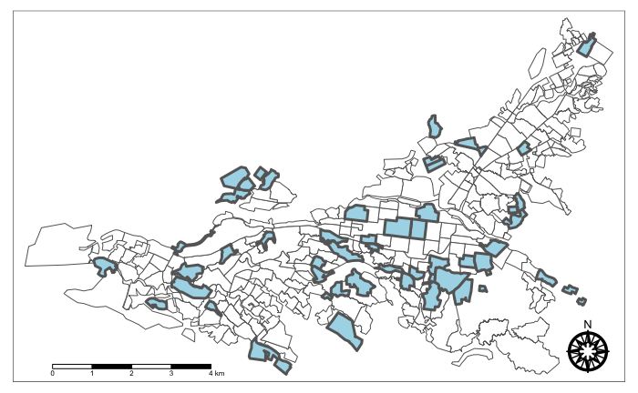

```r
tm_shape(ZonasQuartil) + tm_polygons(col = "white") +
  tm_shape(Test) + tm_polygons(col = "#abd9e9", lwd = 3) +
  tm_compass(size = 3, type = "rose", lwd = 3) +
    tm_scale_bar(position = c(0.06,0))
```

```r
PrincipalesTiempoCarro <- CarroPico %>%
  select(ZAT_INI, ZAT_FIN, TotalViajes, TravelTimePrivate, Estrato) %>% arrange(TotalViajes)
PrincipalesTiempoBici <- CarroPico %>%
  select(ZAT_INI, ZAT_FIN, TotalViajes, TaverlTimeBici, Estrato) %>% arrange(TotalViajes)
```

## Mapa diferencias accesibilidad

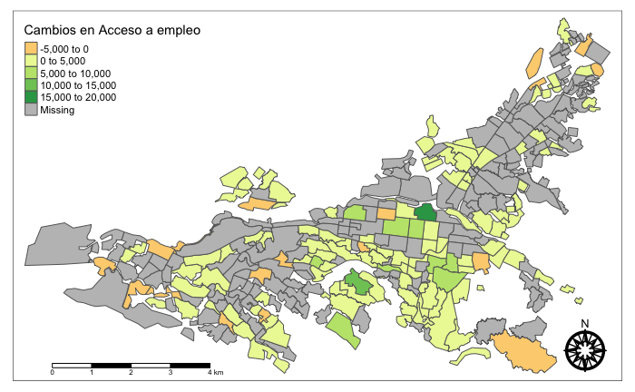

```r
ZonasDiffAcc <- ZonasUrbanas %>% left_join(AccesibilidadDiffEmpleoZonas, by = c("ZONA"="ZAT_INI"))
tm_shape(ZonasDiffAcc) + tm_polygons(col = "Diferencia", title = "Cambios en Acceso a empleo") +
  tm_compass(size = 3, type = "rose", lwd = 3) +
    tm_scale_bar(position = c(0.06,0))
```